# emission-data-package

This vignette summarizes the Lab 5 package and all its functions. To use the package, run the command below :

```r
library(advancedRLab5)
```

## get_figures()

The function `get_figures()` downloads emission data from kolada.se for the municipality chosen by the user. The function argument `muni_name` is the name of the municipality as a string. Here is an example how to use it:

```r
tail(get_figures("Linköping"))
```

```
#>    years   N00401    N85078     N85072    N85075     N85077   N85073   N85076
#> 13  2015 4.702540 0.7692128 0.04921624 0.2113072 0.19218656 1.687472 1.596628
#> 14  2016 4.760052 0.7474836 0.04571006 0.1896786 0.13740388 1.589238 1.857095
#> 15  2017 4.494078 0.7541851 0.04400014 0.1875211 0.17829709 1.402722 1.738194
#> 16  2018 4.497523 0.7276802 0.03706028 0.1734895 0.20133071 1.408479 1.774241
#> 17  2019 4.192727 0.6775155 0.03368058 0.1885327 0.06897754 1.373593 1.684655
#> 18  2020 4.046408 0.7312389 0.02803864 0.1830862 0.03363862 1.243717 1.665838
```

The function returns a `data.frame` containing all the emission data. The columns are:

- years <- the year in which the data has been gathered
- N00401 <- Total greenhouse gas emissions to air, tonnes of CO2 equivalents per capita
- N85078 <- Greenhouse gas emissions to air, agriculture, tonnes of CO2 equivalents per capita
- N85072 <- Greenhouse gas emissions to air, heating, tonnes of CO2 equivalents per capita
- N85075 <- Greenhouse gas emissions to air, machinery, tonnes of CO2 equivalents per capita
- N85077 <- Greenhouse gas emissions to air, industry, tonnes of CO2 equivalents per capita
- N85073 <- Greenhouse gas emissions to air, transport, tonnes of CO2 equivalents per capita
- N85076 <- Greenhouse gas emissions to air, electricity and district heating, tonnes of CO2 equivalents per capita

## plot_figures()

The function `plot_figures()` downloads emission data from kolada.se for the municipality chosen by the user and plots the graphs in different plots. Here is an example how to use it:

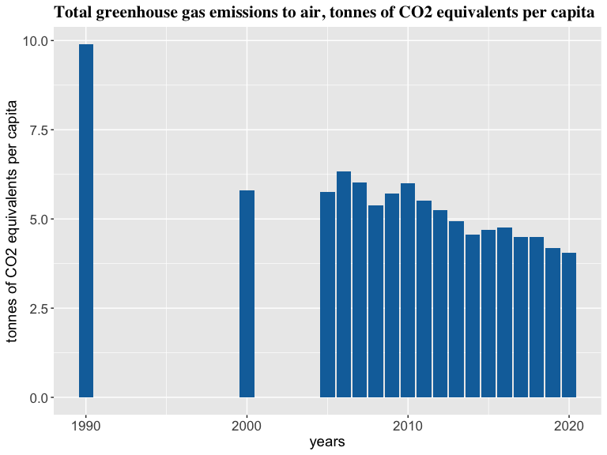

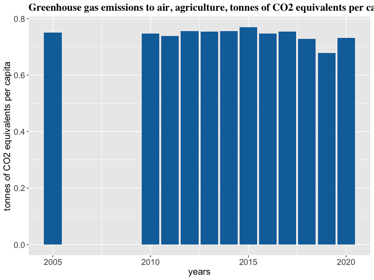

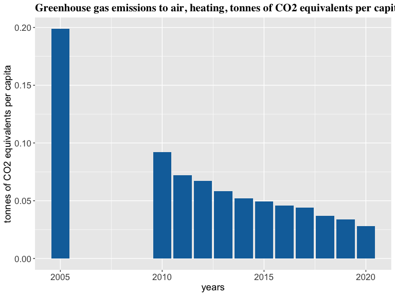

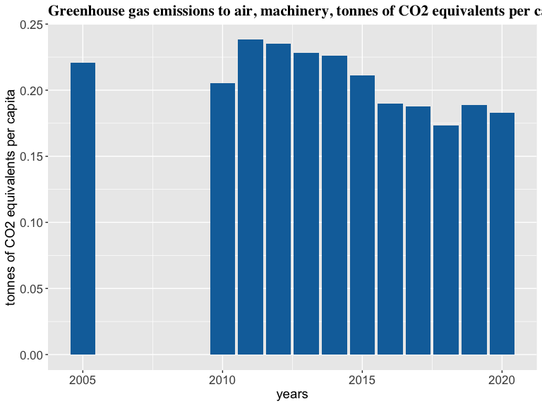

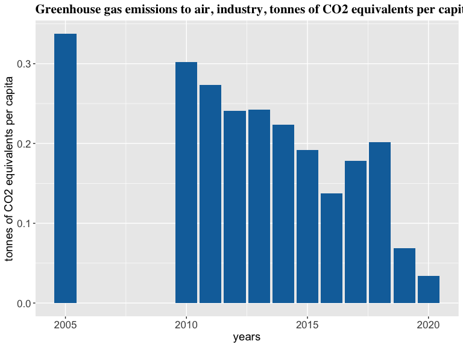

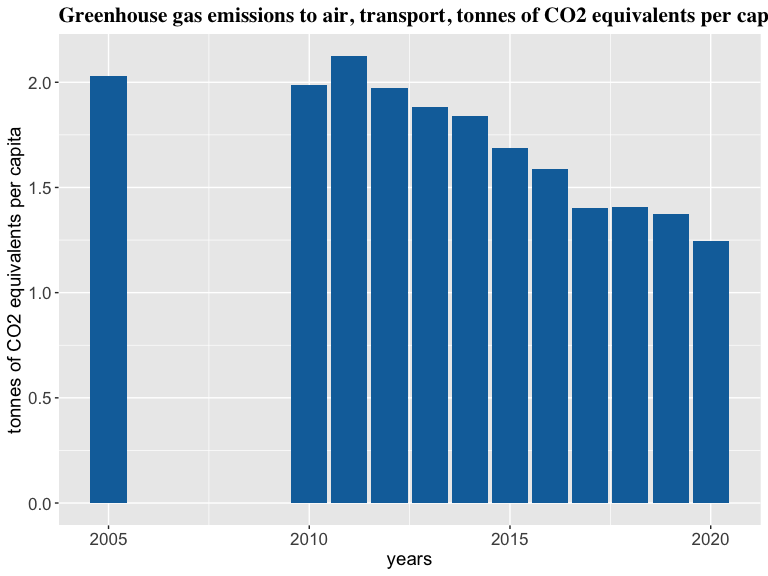

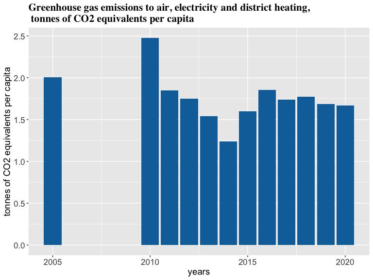

```r
plot_figures("Linköping")
```